# “Александрийский квартет” Л. Дж. Даррелла

Author

Дарья Галкина

Published

December 22, 2024

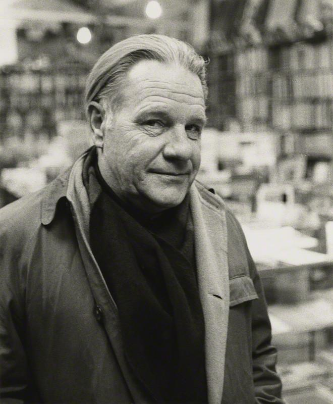

[figure not shown]

Роман состоит из четырёх книг: «Жюстин», «Бальтазар», «Маунтолив» и «Клеа». Первые три книги представляют собой описание одних и тех же событий от лица разных персонажей, а четвёртый роман даёт развитие трём сюжетным линиям, объединяя их. Прекрасный портрет стилистикеского своеобразия романа [даёт](https://www.peremeny.ru/blog/10775) А. Александровская, отмечая дипазон жанрового эксперимента, который предпринимает Даррелл. Так, в “Маунтоливе” читатель узнаёт роман со всеведующих повествователем “во флоберовском вкусе”, “с ясной и рациональной интригой”. В “Жюстин” находит пласт гностического контекста и поэтические аллюзии к К.Кавафису, а в иронично-постмодернистском “Бальтазаре” - таротную символику и многое другое. Комментируя повествовательную структуру романа, А. Александровская [пишет](https://www.peremeny.ru/blog/10775):

> *Роман, созданный как палимпсест: записки Дарли — повествователя — протагониста, комментарии его друга Бальтазара, дневники его возлюбленной Жюстин и ее мужа Нессима, роман первого ее мужа Арноти, записные книжки писателя Персуордена… Точки зрения на происходящее пересекаются, смыкаются, различаются, отрицают друг друга, так что читатель окончательно теряет представление об истине — или хотя бы о возможности ее существования.*

Русский читатель познакомится с серией романов только в 1996-1997 гг. благодаря переводчику В.Ю. Михайлину. Его комментарий к последнему изданию тетралогии можно прочитать [здесь](https://flibusta.su/book/36788-aleksandriyskiy-kvartet/read/?ysclid=m4y8oi1zy1686999536).